# Processamento de Linguagem Natural - NLP

### **Análise de sentimentos aplicado a mensagens do Twitter**

##### Para esse exemplo tentaremos responder a partir de mensagens do Twitter, a seguinte pergunta: **“Qual é o sentimento das pessoas em relação as vacinas?”**.

#### **Requisitos**

1. Ter uma conta no [Twitter](https://twitter.com/).
2. Estar cadastrado como [Twitter Developer](https://developer.twitter.com/).
3. Acesso a API do Twitter.

#### **Pacotes Utilizados**

- **dplyr**: Utilizado para manipulação de manipulação de dados.
- **rtweet**: Faz a interface de conexão entre o R e a API do Twitter.
- **tm**: Possui inúmeras funções direcionadas a atividade de mineração de texto.
- **wordcloud**: Permite para criar uma nuvem de palavras.
- **syuzhet**: Utilizado para classificar os sentimentos. Ele disponibiliza algumas funções úteis para a identificação das emoções presentes em textos, entre elas, a função chamada **get_nrc_sentiment()** que usa um dicionário de termos, denominado de NRC Emotion Lexicon, no qual associa palavras à emoções e sentimentos, afim de realizar a comparação das palavras e identificar as emoções e sentimentos presentes no texto.

#### **Carregando pacotes**

```r
library(dplyr)
library(rtweet)
library(tm)
library(wordcloud)
library(syuzhet)
```

##### **Buscando Tweets com função search_tweets() do pacote rtweet**

```r
vacina_tweets <- search_tweets(
  "#vacina",
  include_rts = FALSE,
  lang = "pt-br"
)
```

##### **Quantidade de Tweets**

```r
nrow(vacina_tweets)
```

```
## [1] 1508
```

##### **Menor data**

```r
min(vacina_tweets$created_at)
```

```
## [1] "2021-04-25 20:17:07 UTC"
```

##### **Maior data**

```r
max(vacina_tweets$created_at)
```

```
## [1] "2021-05-03 19:30:11 UTC"
```

##### **Visualizando a série temporal de frequência dos tweets no decorrer do tempo usando a função ts_plot()**

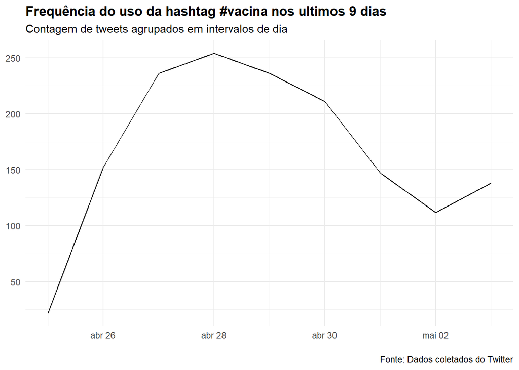

```r
ts_plot(vacina_tweets, "day") +
theme_minimal() +
theme(plot.title = ggplot2::element_text (face = "bold")) +
labs (
      x = NULL, y = NULL,
      title = "Frequência do uso da hashtag #vacina nos ultimos 9 dias",
      subtitle = "Contagem de tweets agrupados em intervalos de dia",
      caption = "\nFonte: Dados coletados do Twitter"
)
```

##### **Separando apenas a coluna de Tweets do DataFrame obtido pelo rtweet**

```r
vacina_text <- vacina_tweets$text
```

#### **Para fazer a limpeza dos textos podemos utilizar as funções do pacote tm, ou podemos criar as nossas próprias funções**

```r
# Função para limpeza dos textos
limpar_texto <- function(texto) {
  # Convertendo o texto para minúsculo
  texto <- tolower(texto)
  # Removendo o usuário adicionado no comentário
  texto <- gsub("@\\w+", "", texto)
  # Removendo as pontuações
  texto <- gsub("[[:punct:]]", "", texto)
  # Removendo links
  texto <- gsub("http\\w+", "", texto)
  # Removendo tabs
  texto <- gsub("[ |\t]{2,}", "", texto)
  # Removendo espaços no início do texto
  texto <- gsub("^ ", "", texto)
  # Removendo espaços no final do texto
  texto <- gsub(" $", "", texto)
  return(texto)
}
```

##### **Executando a função de limpeza de dados**

```r
vacina_text <- limpar_texto(vacina_text)
```

##### **Convertendo os textos em corpus.**

###### **O Corpus, são uma coleção de documentos criada pelo R.**

```r
vacina_corpus <- VCorpus(VectorSource(vacina_text))
```

###### **Stopwords são palavras que não tenham valor semântico, geralmente são palavras conectivas (com, para, e, a).**

```r
vacina_corpus %>% tm_map(removeWords, stopwords("portuguese"))
```

##### **Através de uma Wordcloud podemos visualizar os termos mais frequentes no conjunto de dados**

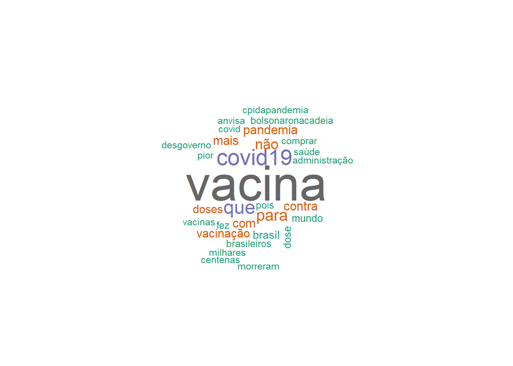

```r
wordcloud(
  vacina_corpus,
  min.freq = 15,
  max.words = 30,
  random.order = F,
  colors = brewer.pal(8, "Dark2")
)
```

##### **Agora transformaremos o corpus em uma matriz de documentos-termos para criarmos um gráfico de barras com os termos e sua frequência.**

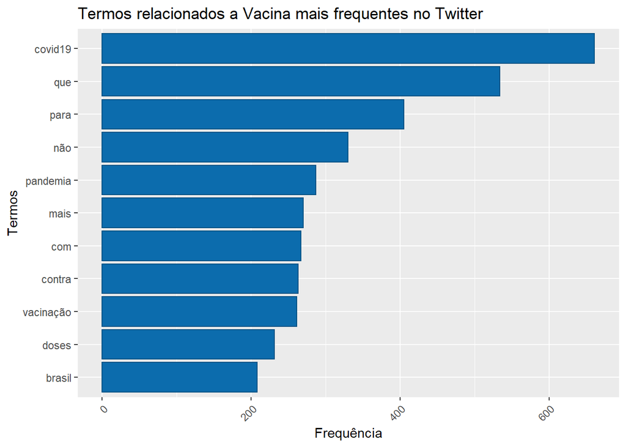

```r
# Transformando o corpus em matriz de documentos-termos
vacina_doc <-  DocumentTermMatrix(vacina_corpus)

# Removendo os termos menos frequentes
vacina_doc1 <- removeSparseTerms(vacina_doc, 0.97)

# Gerando uma matrix ordenada, com o termos mais frequentes
vacina_freq <-
  vacina_doc1 %>%
  as.matrix() %>%
  colSums() %>%
  sort(decreasing = T)

# Criando um dataframe com as palavras mais frequentes
df_vacina_freq <- data.frame(
  word = names(vacina_freq),
  freq = vacina_freq)

# Gerando um gráfico da frequência

df_vacina_freq %>%
  filter(!word %in% c("vacina")) %>%
  subset(freq > 200) %>%
  ggplot(aes(x = reorder(word, freq),y = freq)) +
  geom_bar(stat = "identity", fill='#0c6cad', color="#075284") +
  theme(axis.text.x = element_text(angle = 45, hjus = 1)) +
  ggtitle("Termos relacionados a Vacina mais frequentes no Twitter") +
  labs(y = "Frequência", x = "Termos") +
  coord_flip()
```

##### **Realizando a análise de sentimentos dos tweets.**

##### Para isso utilizaremos a função **get_nrc_sentiment()** do pacote **syuzhet** e passaremos como parâmetro os termos da matriz de documentos-termos. Após obtermos as emoções dos termos, faremos o cálculo da frequência dos sentimentos que utilizaram a **#vacina**.

```r
# Obtendo os emoções
vacina_sentimento <- get_nrc_sentiment(
  vacina_doc$dimnames$Terms,
  language = "portuguese"
)

# Calculando a frequência dos sentimentos
vacina_sentimento_freq <-vacina_sentimento %>%
colSums() %>%
sort(decreasing = T)
```

```r
# Criando um dataframe com os sentimentos traduzidos, que será utilizado como conversão de domínio.
sentimetos_traducao <-
    data.frame(
      sentiment = c(
        "positive",
        "negative",
        "trust",
        "anticipation",
        "fear",
        "joy",
        "sadness",
        "surprise",
        "anger",
        "disgust"
      ),
      sentimentos = c(
        "Positivo",
        "Negativo",
        "Confiança",
        "Expectativa",
        "Medo",
        "Alegria",
        "Tristeza",
        "Surpresa",
        "Raiva",
        "Nojo"
      )
    )

# Tranformando os resultados da frequência em um dataframe e juntando ao dataframe de tradução
df_sentimento <-
  data.frame(
    sentiment = names(vacina_sentimento_freq),
    freq = vacina_sentimento_freq
  ) %>%
  left_join(sentimetos_traducao, by = "sentiment") %>%
  dplyr::select(-sentiment) %>%
  arrange(desc(freq))
```

##### **Visualizando a frequência dos sentimentos em relação a #vacina**

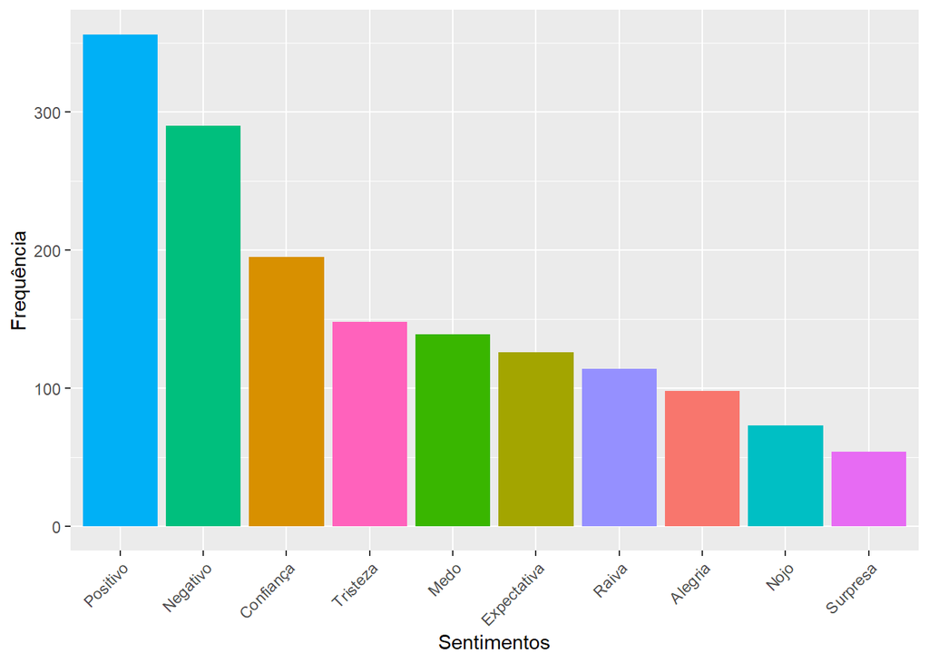

```r
ggplot(data = df_sentimento,
           aes(x = reorder(sentimentos, -freq), y = freq)) +
    geom_bar(aes(fill=sentimentos), stat = "identity") +
    theme(legend.position = "none",
          axis.text.x = element_text(angle = 45, hjus = 1)) +
    xlab("Sentimentos") +
    ylab("Frequência")
```

##### **Referências**

- https://developer.twitter.com/
- http://tm.r-forge.r-project.org
- https://cran.r-project.org/web/packages/syuzhet/vignettes/syuzhet-vignette.html *https://cran.r-project.org/web/packages/rtweet/rtweet.pdf